# Nor Hendra – Fire Point Patterns in Kapuas Regency

## Fire Point Patterns in Kapuas Regency

Nor Hendra  
ISSS626 Geospatial Analytics and Applications  
Take-home Exercise 1

*Data from MODIS FIRMS*  
*Central Kalimantan, 1 January to 11 September 2026*

## Contents

1. **Research question**
2. **Study area and data**
3. **Analytical approach**
4. Key finding: where
5. Key finding: when
6. Clustered beyond chance?
7. Clustered beyond geography?
8. Two distinct regimes (value-added)
9. **Limitations**
10. **Public-safety implications**

## 1 · Research question

Is Kapuas Regency’s 2026 fire activity spatially clustered beyond what its already-known fire-prone geography would predict? If so, at what spatial scales?

The descriptive half

Where is fire intensity highest, and is that concentration statistically real rather than small-sample variation?

→ *first-order analysis*

The demanding half

Once we grant that some parts of Kapuas are already more fire-prone, does an **unexplained** clustering signal remain?

→ *second-order analysis, against an intensity-adjusted reference*

## 2 · Study area and data

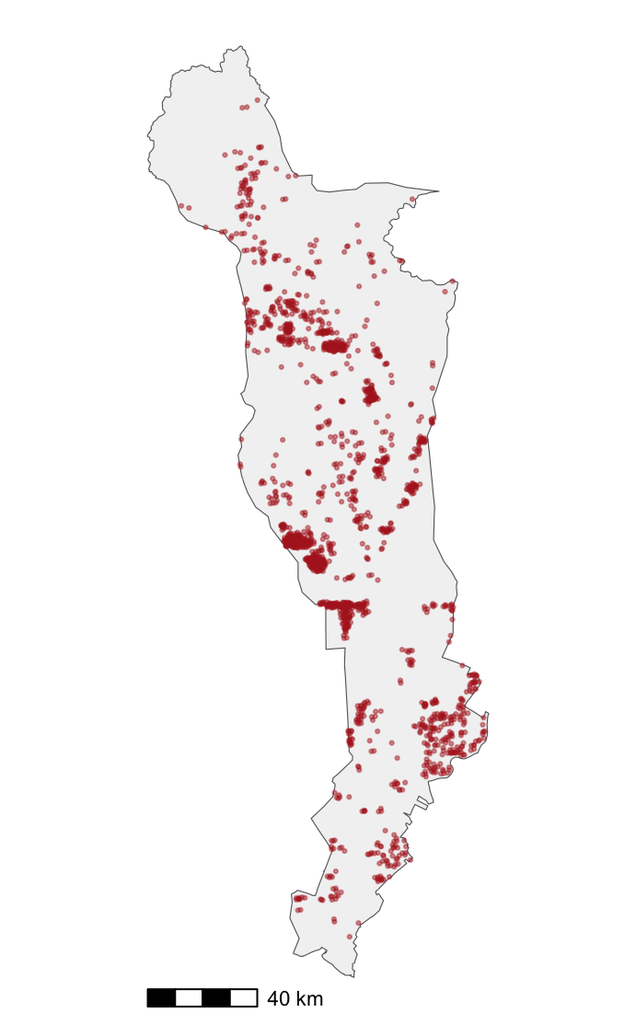

**Selection was data-driven, not chosen then justified.** All 44 eligible Kalimantan regencies were screened on fire count and spread ratio; Kapuas is one of only two combining a substantial count with a spread ratio above 1.3 (1.308).

Corroborated independently: most of the Mega Rice Project’s drained peatland falls within Kapuas, a documented driver of fire along roads and rivers (Thoha et al., 2019).

## 3 · Analytical approach

1

**First-order**

Where is intensity elevated?

Fixed-bandwidth KDE, `bw.ppl()` = 1.113 km

Quadrat test vs CSR

2

**Second-order, flat null**

Is there interaction beyond randomness?

G, F, K / L against complete spatial randomness

*Baseline only: the null is already known to be false for Kapuas*

3

**Second-order, adjusted null**

Does clustering survive known geography?

Kinhom, Ginhom, Finhom against Kapuas’s own estimated intensity

*Carries the interpretive weight*

4

**Value-added**

Does pooling hide two regimes?

Period split at the dry-season onset; KDE and L-function per period

Stages 2 and 3 differ only in their null model, so running both also serves as a sensitivity analysis on the reference itself.

## 4 · Where: one dominant hotspot

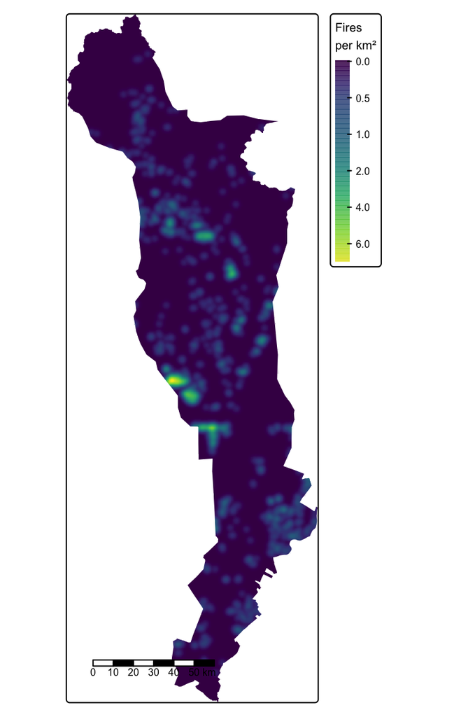

- A single dominant hotspot at 114.146°E, 2.022°S, reaching 7.69 fires/km², more than triple any other elevated area.
- Beyond it, a chain of smaller 1 to 2 fires/km² patches on a similar north to south alignment, forming a loose alignment of distinct clusters rather than one continuous band.
- The quadrat test rejects uniform intensity decisively (X² = 3785.9, df = 45, p < 2.2 × 10⁻¹⁶).
- The KDE peak falls inside the highest-count tile (412 detections, 561.9 km²), verified by containment testing rather than read off the map.

* Intensity is not risk. This surface records where fires were detected, which depends on satellite overpass, cloud cover and terrain as well as on fire occurrence.

## 5 · When: a late-season surge

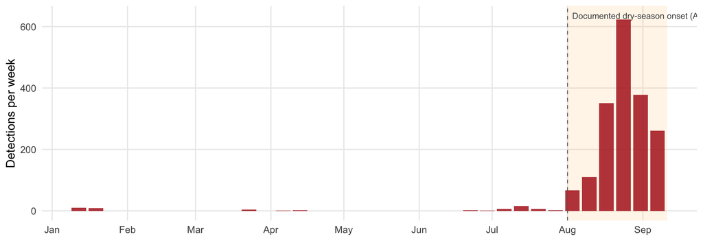

A step change. Only 3.19% of the season’s fires had occurred by 1 August.

Peak week 24 Aug. 623 detections, 89.0 fires per day.

A plateau after the peak. Activity held near 52 to 54 fires per day to the close of the window. 90% was reached only on 10 Sep.

## 6 · Clustered beyond chance?

Reference model · complete spatial randomness, fires equally likely anywhere in Kapuas

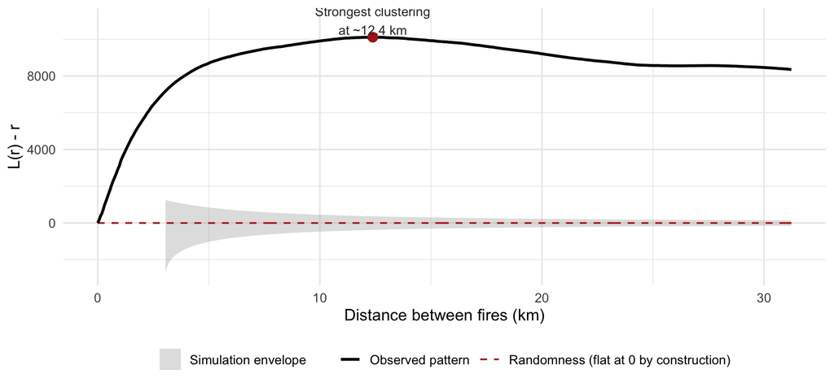

Observed L sits above the envelope at 501 of 512 tested distances, peaking near 12.4 km and staying clear of the band out to 31.2 km. The 11 exceptions are confined to the shortest distances, before the curve climbs above the envelope. The reference itself is not appropriate here. *Where: one dominant hotspot* already showed intensity is far from uniform, so part of this departure may simply be geography. *Clustered beyond geography?* puts that to the test.

## 7 · Clustered beyond geography?

Reference model · Kapuas’s own estimated intensity surface, known fire-prone areas already built in

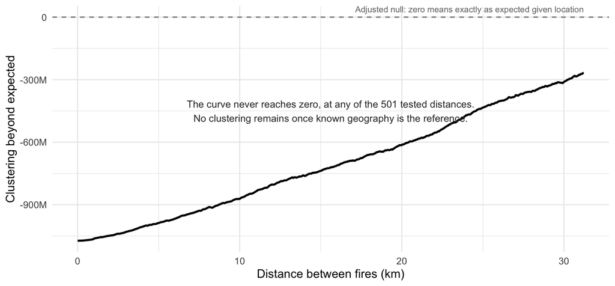

The answer is no. `Kinhom` exceeds the adjusted null at 0 of 501 tested distances. Even at its closest approach, near 31.2 km, the observed curve stays below the bound. `Finhom` and `Ginhom` agree from different constructions, departing at only 10 of 95 and 4 of 95 distances, with largest magnitudes of 0.0155 and 0.0057, too small and too scattered to claim either clustering or regularity. The large departure in *Clustered beyond chance?* was Kapuas’s geography expressing itself, rather than fires interacting with each other.

## 8 · Two distinct regimes

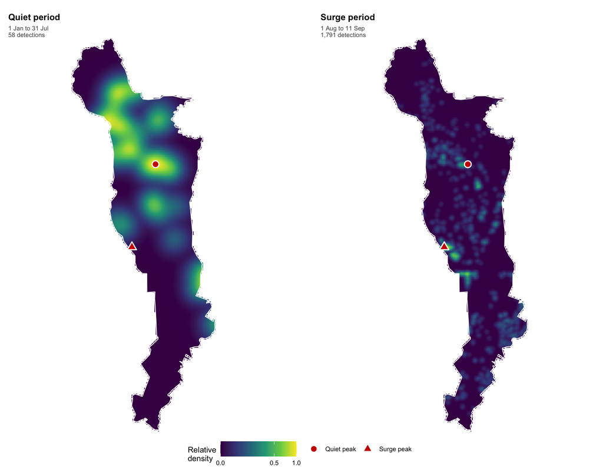

The dominant hotspot did not form where the early activity was.

- Peaks sit 75.1 km apart, at roughly 289× lower quiet intensity.
- Bandwidth: 6.65 km quiet, 1.113 km surge.
- The surge is strongly clustered against CSR, at 478 of 513 distances.
- The quiet period is indistinguishable from randomness at 58 points (4 of 513).
- Only the surge’s scale is supported: about 4.6 km, tighter than the pooled 12.4 km.
- The two-regime case rests on the first-order contrast. Colour is scaled per panel, so magnitudes are not comparable.

## 9 · Limitations

- Detection, not occurrence  
  MODIS about 1 km resolution and revisit geometry mean reliability varies with cloud, terrain and overpass timing. Lower measured intensity does not mean less fire. This caveat attaches to every intensity and clustering based finding.
- A circular reference  
  Stage 3’s intensity surface is estimated from the same 1,849 points it tests. It answers “clustering beyond *this estimate*,” not beyond the true intensity. This is standard for the diagnostic, but it means the null absorbs whatever the estimate already encodes.
- One season  
  No multi-year baseline. Whether 2026’s timing or magnitude is typical cannot be determined here.
- Bandwidth sensitivity  
  `bw.ppl()` and `bw.diggle()` disagreed by roughly a factor of two (1.113 vs 0.550 km); fixed and adaptive KDE produced visibly different surfaces. Documented rather than resolved.
- Pooled temporal treatment  
  The main analysis treats the full window as one cross-section despite activity concentrating in the final six weeks. *Two distinct regimes* examines the split, at reduced power.
- Unresolved mechanism  
  The intensity surface accounts for almost all of the second-order structure, but it is only a proxy for whatever makes some areas fire-prone. Road and river accessibility, fire-to-fire spread and uneven detection cannot be distinguished with fire-detection data alone.

## 10 · Public-safety implications

[figure not shown]

Supported directly by the analysis

Motivated, but requiring further data

- Cause. Three mechanisms remain indistinguishable. Policy should not be justified as addressing a cause until a covariate model is built.
- BPBD proximity. Facility locations matter analytically, but no distances were computed, so coverage claims would be speculation.
- Permanent infrastructure. One season cannot support fixed rather than seasonal capacity.
- Risk itself. Intensity is not risk. Treat this surface as a hypothesis for field verification.